# HW 6

Data 180, Professor Bilen

Song Yun

yuns@dickinson.edu

November 09, 2022

**Due date:** November 10 beginning of class.

The file `Milk_Composition.csv` is available in the same hw folder as this .Rmd file on Github (Real Data!). The file contains the composition of milk for a set of mammals. The variables measured are the compositions (as a percentage) of five milk constituents: Water, Protein, Fat, Lactose, and Ash. (Ash is a term used to describe inorganic residue from the incineration of organic matter and is mostly minerals).

Read this table into R and create the object `Mammals_Milk` using

```r
library(tidyverse)
Mammals_Milk<-read.csv("Milk_Composition.csv",header=T,row.names=1)
head(Mammals_Milk)
```

```
##           Water Protein Fat Lactose  Ash
## Horse      90.1     2.6 1.0     6.9 0.35
## Orangutan  88.5     1.4 3.5     6.0 0.24
## Monkey     88.4     2.2 2.7     6.4 0.18
## Donkey     90.3     1.7 1.4     6.2 0.40
## Hippo      90.4     0.6 4.5     4.4 0.10
## Camel      87.7     3.5 3.4     4.8 0.71
```

# Question 1

Use the `summary()` function to produce a summary of the variables (mean, median..) in the Mammals_Milk data frame.

```r
summary(Mammals_Milk)
```

```
##      Water          Protein            Fat           Lactose
##  Min.   :44.90   Min.   : 0.600   Min.   : 1.00   Min.   :0.000
##  1st Qu.:72.05   1st Qu.: 2.900   1st Qu.: 3.35   1st Qu.:2.925
##  Median :82.05   Median : 5.750   Median : 6.10   Median :4.700
##  Mean   :78.47   Mean   : 5.958   Mean   :10.19   Mean   :4.225
##  3rd Qu.:87.88   3rd Qu.: 9.400   3rd Qu.:13.85   3rd Qu.:5.600
##  Max.   :90.40   Max.   :11.100   Max.   :42.00   Max.   :6.900
##       Ash
##  Min.   :0.1000
##  1st Qu.:0.5150
##  Median :0.7900
##  Mean   :0.7679
##  3rd Qu.:0.9150
##  Max.   :1.4000
```

To have comparable units, let’s standardize values (aka get z-scores) of the five variables: Water, Protein, Fat, Lactose, and Ash using the scale function and store it as an object `Mammals_Milk_Std`. A 0 z-score means an observation is exactly on its mean; a negative value means it’s smaller than mean; a larger number means it’s larger than the mean. ([Here is a nice summary on z-scores](https://www.simplypsychology.org/z-score.html)). Use this standardized object when indicated in the next questions.

```r
Mammals_Milk_Std<-as.data.frame(round(scale(Mammals_Milk),2))
head(Mammals_Milk_Std)
```

```
##           Water Protein   Fat Lactose   Ash
## Horse      0.89   -0.96 -0.86    1.48 -1.13
## Orangutan  0.77   -1.30 -0.62    0.98 -1.43
## Monkey     0.76   -1.07 -0.70    1.20 -1.59
## Donkey     0.91   -1.22 -0.82    1.09 -1.00
## Hippo      0.92   -1.53 -0.53    0.10 -1.81
## Camel      0.71   -0.70 -0.63    0.32 -0.16
```

# Question 2

Use hierarchical clustering (i.e. `hclust`) to cluster the animals based on the standardized composition of their milk. Use the Euclidean metric and complete linkage. Plot the dendrogram of the clustering. In your dendrogram:

- Set the line width to 3
- Set the title to “Mammals Clustered by Std. Milk Composition Euclidean Metric, Complete Linkage”
- Remove the subtitle by setting sub= “”
- Set the x-axis label to “Mammals” with cex.lab=1.25
- Have the terminal edges extend to the 0 height by setting hang=-1
- Set the frame.plot argument to T to draw a box around the dendrograms

```r
m_cluster <- hclust(dist(Mammals_Milk_Std))
m_cluster
```

```
##
## Call:
## hclust(d = dist(Mammals_Milk_Std))
##
## Cluster method   : complete
## Distance         : euclidean
## Number of objects: 24
```

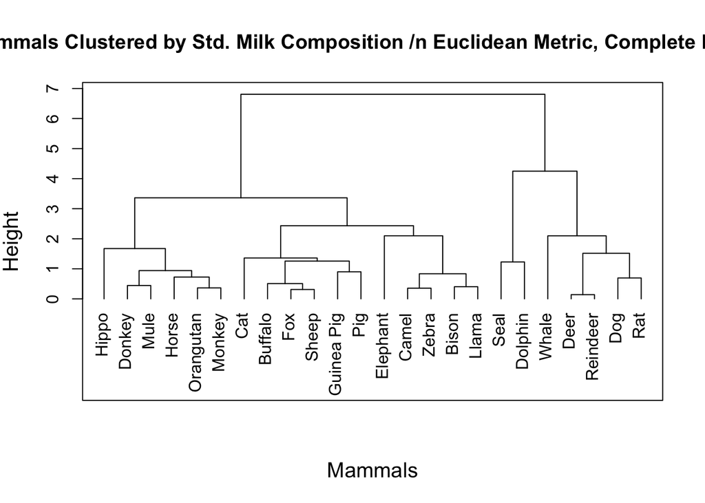

```r
plot(m_cluster, sub = "",cex.lab = 1.25,xlab = "Mammals", frame.plot = T,hang = -1, main = "Mammals Clustered by Std. Milk Composition /n Euclidean Metric, Complete Linkage" )
```

# Question 3

```r
set.seed(125)

MMilk_km_3 <- kmeans(Mammals_Milk_Std, centers=3, nstart=100)
MMilk_km_4 <- kmeans(Mammals_Milk_Std, centers=3, nstart=100)
Mammals_Milk_Std$km_3 <- MMilk_km_3$cluster
Mammals_Milk_Std$km_4  <- MMilk_km_4$cluster
arrange(Mammals_Milk_Std)
```

```
##            Water Protein   Fat Lactose   Ash km_3 km_4
## Horse       0.89   -0.96 -0.86    1.48 -1.13    3    3
## Orangutan   0.77   -1.30 -0.62    0.98 -1.43    3    3
## Monkey      0.76   -1.07 -0.70    1.20 -1.59    3    3
## Donkey      0.91   -1.22 -0.82    1.09 -1.00    3    3
## Hippo       0.92   -1.53 -0.53    0.10 -1.81    3    3
## Camel       0.71   -0.70 -0.63    0.32 -0.16    3    3
## Bison       0.65   -0.33 -0.79    0.81  0.36    3    3
## Buffalo     0.28   -0.02 -0.21    0.26  0.03    3    3
## Guinea Pig  0.26    0.41 -0.28   -0.84  0.22    2    1
## Cat         0.24    1.18 -0.36    0.10 -0.05    2    1
## Fox         0.24    0.18 -0.40    0.37  0.44    3    3
## Llama       0.62   -0.59 -0.65    0.76  0.09    3    3
## Mule        0.89   -1.13 -0.78    0.70 -0.81    3    3
## Pig         0.33    0.33 -0.47   -0.29  0.90    2    1
## Zebra       0.59   -0.85 -0.50    0.59 -0.18    3    3
## Sheep       0.27   -0.10 -0.35    0.26  0.38    3    3
## Dog        -0.17    0.96 -0.06   -0.68  1.17    2    1
## Elephant   -0.60   -0.67  0.69    0.76 -0.37    3    3
## Rat        -0.46    0.93  0.22   -0.51  1.71    2    1
## Deer       -0.97    1.27  0.89   -0.90  1.71    2    1
## Reindeer   -1.05    1.36  0.94   -0.95  1.71    2    1
## Whale      -1.05    1.47  1.03   -1.45  0.22    2    1
## Seal       -2.46    1.07  2.97   -2.33  0.22    1    2
## Dolphin    -2.58    1.33  2.30   -1.84 -0.64    1    2
```

```r
#Mammals_Milk_Std %>% arrange(km3,by_group = T)
```

# Question 4

- `Count`: the group size
- `Mean_Water` the mean water content
- `Mean_Protein` the mean protein content
- `Mean_Fat` the mean fat content
- `Mean_Lactose` the mean lactose content
- `Mean_Ash` the mean ash content

Call the summary tables `MMilk_Agg_K3` and `MMilk_Agg_K4`. Round the elements in the data frames to the hundredths place and paste them into your solutions.

```r
MMilk_Agg_K3 <- Mammals_Milk_Std %>% group_by(km_3) %>% summarise(Mean_Water = mean(Water),Mean_Protein = mean(Protein),Mena_Fat = mean(Fat),Mean_Lactose = mean(Lactose),Mean_Ash = mean(Ash))
MMilk_Agg_K3
```

```
## # A tibble: 3 × 6
##    km_3 Mean_Water Mean_Protein Mena_Fat Mean_Lactose Mean_Ash
##   <int>      <dbl>        <dbl>    <dbl>        <dbl>    <dbl>
## 1     1     -2.52         1.2      2.64        -2.08    -0.21
## 2     2     -0.359        0.989    0.239       -0.69     0.949
## 3     3      0.564       -0.735   -0.511        0.691   -0.513
```

```r
MMilk_Agg_K4 <- Mammals_Milk_Std %>% group_by(km_4) %>% summarise(Mean_Water = mean(Water),Mean_Protein = mean(Protein),Mena_Fat = mean(Fat),Mean_Lactose = mean(Lactose),Mean_Ash = mean(Ash))
MMilk_Agg_K4
```

```
## # A tibble: 3 × 6
##    km_4 Mean_Water Mean_Protein Mena_Fat Mean_Lactose Mean_Ash
##   <int>      <dbl>        <dbl>    <dbl>        <dbl>    <dbl>
## 1     1     -0.359        0.989    0.239       -0.69     0.949
## 2     2     -2.52         1.2      2.64        -2.08    -0.21
## 3     3      0.564       -0.735   -0.511        0.691   -0.513
```

# Question 5

For the K=3 solution, make a set of boxplots showing the distribution of each variable by cluster membership. In total you should have five graphs (one for each variable in the dataset). Each graph should include three boxplots (one for each cluster). *Hint:* Use `ggplot2` with `geom_boxplot` and create five different ggplot objects. Name them as graph1, graph2,… as below. Finally, use the library named `cowplot` which includes the function `plot_grid()` that enables plotting multiple graphs side by side. See more in the cell below. Make sure to change `eval=F` to `eval=T` in its options when you execute the cell.

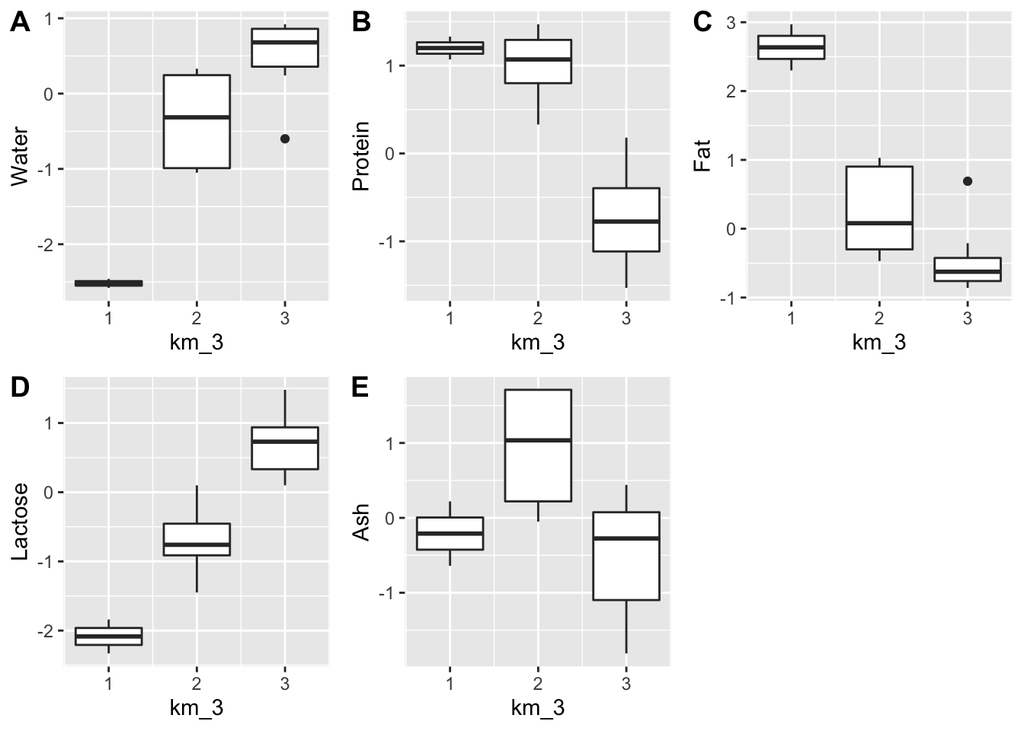

```r
require(cowplot)
graph1 <- ggplot(data = Mammals_Milk_Std,aes(x= km_3, y=Water,group=km_3)) + geom_boxplot()
graph2 <- ggplot(data = Mammals_Milk_Std,aes(x= km_3, y=Protein,group=km_3)) + geom_boxplot()
graph3 <- ggplot(data = Mammals_Milk_Std,aes(x=km_3, y=Fat,group=km_3)) + geom_boxplot()
graph4 <- ggplot(data = Mammals_Milk_Std,aes(x=km_3, y=Lactose,group=km_3)) + geom_boxplot()
graph5 <- ggplot(data = Mammals_Milk_Std,aes(x=km_3, y=Ash,group=km_3)) + geom_boxplot()
plot_grid(graph1, graph2, graph3, graph4, graph5, labels = "AUTO")
```

# Question 6

You are done! 🏁 Don’t forget to commit and push your .Rmd file to your Github repository before the due date.